# Task 4

Hannes Guth

2023-03-21

```r
library(fpp3) # package with different function, amongst other add_column()
library(ggplot2) # package for creating plots
library(data.table) # package to handle data tables
library(dplyr) # package to use the pipe operator
library(knitr) # package to present tables
library(geomtextpath) # package to add labels in ggplots
```

## a.

#### Set the two Holt’s model with additive ETS(A,A,N).

The data is being loaded as a first step and then transformed into a tsibble object that is the following.

```r
books = data.table(read.csv2("books.csv", sep=";")) # read the data set and convert it to a data table
books = add_column(books, time = seq(1,30,1), .before = 1) # add a column for numerating from 1:30 as a time index
books_tsibble = as_tsibble(books,
                           index = time) # create a new tsibble object from the data table
kable(head(books_tsibble, 6)) # present the head of the table
```

| time | Paperback | Hardcover |
| --- | --- | --- |
| 1 | 199 | 139 |
| 2 | 172 | 128 |
| 3 | 111 | 172 |
| 4 | 209 | 139 |
| 5 | 161 | 191 |
| 6 | 119 | 168 |

In this paragraph, the two models are established. They shall have an additive error, an additive trend and no seasonality.

```r
# create a model for the hardcover, using the previously created tsibble object
holt_hardcover = books_tsibble %>%
  model(
    `Holt_Hardcover` = ETS(Hardcover ~ error("A") + trend("A") + season("N"))
  )

# create a model for the paperback, using the previously created tsibble object
holt_paperback = books_tsibble %>%
  model(
    `Holt_Paperback` = ETS(Paperback ~ error("A") + trend("A") + season("N"))
  )
```

Showing the report of the models give amongst others information about the variance of the models that will be needed in the upcoming steps.

```r
report(holt_hardcover) # show the report of the hardcover model
```

```
## Series: Hardcover
## Model: ETS(A,A,N)
##   Smoothing parameters:
##     alpha = 0.0001000484
##     beta  = 0.0001000231
##
##   Initial states:
##      l[0]     b[0]
##  147.7935 3.302946
##
##   sigma^2:  853.2586
##
##      AIC     AICc      BIC
## 310.2148 312.7148 317.2208
```

```r
report(holt_paperback) # show the report of the paperback model
```

```
## Series: Paperback
## Model: ETS(A,A,N)
##   Smoothing parameters:
##     alpha = 0.0001002281
##     beta  = 0.0001000024
##
##   Initial states:
##     l[0]     b[0]
##  170.699 1.261911
##
##   sigma^2:  1118.663
##
##      AIC     AICc      BIC
## 318.3396 320.8396 325.3456
```

From this point, one calculates the standard deviations of the respective models.

```r
# calculate the standard deviations from the retrieved variances
std_H = as.integer(sqrt(853.2586))
std_P = as.integer(sqrt(1118.663))

# show the standard deviations
paste("Standard deviation hardcover:", std_H)
```

```
## [1] "Standard deviation hardcover: 29"
```

```r
paste("Standard deviation paperback:", std_P)
```

```
## [1] "Standard deviation paperback: 33"
```

The levels and trends of the models are taken from the components and have the following values.

```r
# take the last observation of the components of the 2 models at level and trend
LH_30 = components(holt_hardcover)[31,4]
TH_30 = components(holt_hardcover)[31,5]

LP_30 = components(holt_paperback)[31,4]
TP_30 = components(holt_paperback)[31,5]

# show the values
paste("Level hardover at period 30:", round(LH_30))
```

```
## [1] "Level hardover at period 30: 247"
```

```r
paste("Trend hardcover at period 30:", round(TH_30, 2))
```

```
## [1] "Trend hardcover at period 30: 3.3"
```

```r
paste("Level paperback at period 30:", round(LP_30))
```

```
## [1] "Level paperback at period 30: 208"
```

```r
paste("Trend paperback at period 30:", round(TP_30, 2))
```

```
## [1] "Trend paperback at period 30: 1.25"
```

The hardcover books have a bigger trend and also a higher value in the 30th period than the ones with a paperback.

## b.

#### Simulate 2 sets of 1000 random normal variables associated with each model.

As a first step, 1000 random values with the properties (mean and standard deviation) of the models will be created.

```r
set.seed(1) # for reproducibility

# generate 1000 random samples with the respective mean and standard deviation of the models
randomH = rnorm(n = 1000, as.integer(LH_30 + TH_30), std_H)

set.seed(1) # for reproducibility
randomP = rnorm(n = 1000, as.integer(LP_30 + TP_30), std_P)
```

As a second step, a new data table will be created to store the previously obtained results.

```r
# generate a table to store the results
random_var = data.table("Number" = seq(1,1000,1),
                        "randomH" = randomH,
                        "randomP" = randomP)

# show the head of the table
kable(head(random_var, 6))
```

| Number | randomH | randomP |
| --- | --- | --- |
| 1 | 231.8328 | 188.3270 |
| 2 | 255.3257 | 215.0602 |
| 3 | 225.7668 | 181.4243 |
| 4 | 296.2631 | 261.6443 |
| 5 | 259.5557 | 219.8738 |
| 6 | 226.2064 | 181.9245 |

To get a better impression of the distribution of the generated values of the two models, they will be presented graphically.

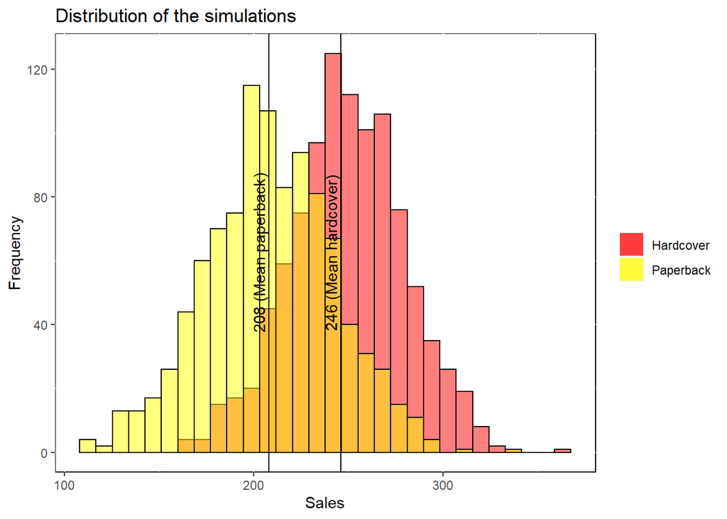

```r
options(scipen=999) # avoid scientific notation

ggplot(random_var) + # create new ggplot with random_var as input data
  geom_bar(stat = "bin", aes(x = randomH, fill = "Hardcover", color = "Hardcover"), alpha = 0.5) + # one set of bars for Hardcover, alpha for transparency
  geom_bar(stat = "bin", aes(x = randomP, fill = "Paperback", color = "Paperback"),  alpha = 0.5) + # one set of bars for Paperback, alpha for transparency
  scale_color_manual(values = c("Hardcover" = "black",
                                "Paperback" = "black")) + # set the color for the borders
  scale_fill_manual(values = c("Hardcover" = "red",
                                "Paperback" = "yellow")) + # set the color for the filling
  theme(legend.title = element_blank(),
        panel.background = element_rect(fill = "white", colour = "black"),
        panel.grid.major = element_line(colour = "white", size = 0.5)) + # remove the legend title and set a white background
  labs(title = "Distribution of the simulations",
       x = "Sales",
       y = "Frequency") + # edit the labels
  guides(color = "none") + # remove the legend for the borders
  geom_textvline(xintercept = as.integer(LH_30),
                 label = paste(as.integer(LH_30), "(Mean hardcover)"),
                 color = "black",
                 offset = -0.2) + # label the mean of the hardcover distribution
    geom_textvline(xintercept = as.integer(LP_30),
                 label = paste(as.integer(LP_30), "(Mean paperback)"),
                 color = "black",
                 offset = -0.2)  # label the mean of the paperback distribution
```

## c.

#### Estimate the probability P(yt+1 > wt+1) for the corresponding proportion.

To calculate the percentage of the cases when the hardcover sales are smaller than the paperback sales, one can compare the single observations of the two distributions pairwise and then average over them.

```r
round(mean(outer(random_var$randomP, random_var$randomH, ">")), 4) * 100 # compare the observations of the two simulations pairwise and average over them
```

```
## [1] 18.29
```

The estimated percentage of paperback sales being bigger than hardcover sales is 18.29 %.

## References

#### Packages

Hyndman R (2023). *fpp3: Data for “Forecasting: Principles and Practice” (3rd Edition)*. R package version 0.5, https://CRAN.R-project.org/package=fpp3.

H. Wickham. ggplot2: Elegant Graphics for Data Analysis. Springer-Verlag New York, 2016.

Dowle M, Srinivasan A (2021). *data.table: Extension of `data.frame`*. R package version 1.14.2, https://CRAN.R-project.org/package=data.table.

Wickham H, François R, Henry L, Müller K (2022). *dplyr: A Grammar of Data Manipulation*. R package version 1.0.10, https://CRAN.R-project.org/package=dplyr.

Yihui Xie (2022). knitr: A General-Purpose Package for Dynamic Report Generation in R. R package version 1.40.

Yihui Xie (2015) Dynamic Documents with R and knitr. 2nd edition. Chapman and Hall/CRC. ISBN 978-1498716963

Yihui Xie (2014) knitr: A Comprehensive Tool for Reproducible Research in R. In Victoria Stodden, Friedrich Leisch and Roger D. Peng, editors, Implementing Reproducible Computational Research. Chapman and Hall/CRC. ISBN 978-1466561595

Cameron A, van den Brand T (2022). *geomtextpath: Curved Text in ‘ggplot2’*. R package version 0.1.1, https://CRAN.R-project.org/package=geomtextpath.